```r
dataset = read.csv('cleaned603dataset_-_dataset603_1.csv')
head(dataset)
```

```
##   PropertyID Property_Type NumberofBuildings Year_Built Property_GFA
## 1    6169481        Office                 1       1981         7770
## 2    6305956        Office                 1       1974         6681
## 3    6506773        Office                 1       2008        14548
## 4    6731628        Office                 1       2017         5223
## 5    6867796        Office                 1       1990          540
## 6    8854296        Office                 1       1979        17468
##   Site_Energy WeatherNormalizedSiteEnergyUse SiteEUI WeatherNormalizedSiteEUI
## 1     10118.0                         9899.1    1.30                     1.27
## 2      4792.7                         4706.3    0.72                     0.70
## 3     11983.9                        11805.9    0.82                     0.81
## 4      3653.5                         3588.3    0.70                     0.69
## 5       506.1                          494.7    0.94                     0.92
## 6     14092.5                        13802.8    0.81                     0.79
##   SourceEnergyUse WeatherNormalizedSourceEnergyUse SourceEUI
```

[output cut: 34 more lines]

```r
options(scipen = 999)
```

```r
fullmodel <-lm(Site_Energy~factor(Property_Type)+NumberofBuildings+Year_Built+Property_GFA+WeatherNormalizedSiteEnergyUse+SiteEUI+WeatherNormalizedSiteEUI+SourceEnergyUse+WeatherNormalizedSourceEnergyUse+SourceEUI+WeatherNormalizedSource.EUI+Emissions_CO2+Emissions_Intensity+DirectGHGEmissions+DirectGHGEmissionsIntensity+Electricity+Natural_Gas+YearEnding+Precipitation+Corn_Heat_Unit+Heating_Degree_Days+Cooling_Degree_Days, data=dataset)

summary(fullmodel)
```

```
##
## Call:
## lm(formula = Site_Energy ~ factor(Property_Type) + NumberofBuildings +
##     Year_Built + Property_GFA + WeatherNormalizedSiteEnergyUse +
##     SiteEUI + WeatherNormalizedSiteEUI + SourceEnergyUse + WeatherNormalizedSourceEnergyUse +
##     SourceEUI + WeatherNormalizedSource.EUI + Emissions_CO2 +
##     Emissions_Intensity + DirectGHGEmissions + DirectGHGEmissionsIntensity +
##     Electricity + Natural_Gas + YearEnding + Precipitation +
##     Corn_Heat_Unit + Heating_Degree_Days + Cooling_Degree_Days,
##     data = dataset)
##
## Residuals:
##      Min       1Q   Median       3Q      Max
## -0.33550 -0.09134  0.00039  0.08570  0.26818
##
## Coefficients: (6 not defined because of singularities)
##                                                                            Estimate
## (Intercept)                                                           28.7659833554
## factor(Property_Type)Fire Station                                      0.0884312170
## factor(Property_Type)Fitness Center/Health Club/Gym                    0.0790569639
## factor(Property_Type)Heated Swimming Pool                              0.1346219523
## factor(Property_Type)Ice/Curling Rink                                  0.1174324194
## factor(Property_Type)Indoor Arena                                      0.0590910333
## factor(Property_Type)Mixed Use Property                                0.1954009645
## factor(Property_Type)Museum                                            0.2062339422
## factor(Property_Type)Non-Refrigerated Warehouse                        0.0095253776
## factor(Property_Type)Office                                            0.1118708267
## factor(Property_Type)Other - Public Services                           0.0574617103
## factor(Property_Type)Other - Recreation                               -0.0151777546
## factor(Property_Type)Performing Arts                                   0.1271807847
## factor(Property_Type)Repair Services (Vehicle, Shoe, Locksmith, etc.)  0.0554254508
## factor(Property_Type)Self-Storage Facility                             0.0833856661
## factor(Property_Type)Social/Meeting Hall                              -0.0205276681
## NumberofBuildings                                                     -0.0112749264
## Year_Built                                                             0.0007085271
## Property_GFA                                                           0.0000030241
## WeatherNormalizedSiteEnergyUse                                         0.0002073388
## SiteEUI                                                               -0.3217617727
## WeatherNormalizedSiteEUI                                               1.8022868623
## SourceEnergyUse                                                        1.0000705939
```

[output cut: 173 more lines]

```
## YearEnding
## Precipitation416.3
## Precipitation832.8
## Corn_Heat_Unit2,193.00
## Corn_Heat_Unit2,305.00
## Heating_Degree_Days4,970.20
## Heating_Degree_Days5,335.70
## Cooling_Degree_Days
## ---
## Signif. codes:  0 '***' 0.001 '**' 0.01 '*' 0.05 '.' 0.1 ' ' 1
##
## Residual standard error: 0.1246 on 257 degrees of freedom
##   (6 observations deleted due to missingness)
## Multiple R-squared:      1,  Adjusted R-squared:      1
## F-statistic: 1.575e+11 on 33 and 257 DF,  p-value: < 0.00000000000000022
```

```r
library(mctest)
```

```r
imcdiag(fullmodel, method='VIF')
```

```
##
## Call:
## imcdiag(mod = fullmodel, method = "VIF")
##
##
##  VIF Multicollinearity Diagnostics
##
##                                                                                  VIF
## factor(Property_Type)Fire Station                                           164.6769
## factor(Property_Type)Fitness Center/Health Club/Gym                          52.8531
## factor(Property_Type)Heated Swimming Pool                                    21.7378
## factor(Property_Type)Ice/Curling Rink                                        62.8992
## factor(Property_Type)Indoor Arena                                             5.7957
## factor(Property_Type)Mixed Use Property                                       8.4714
## factor(Property_Type)Museum                                                   7.8912
## factor(Property_Type)Non-Refrigerated Warehouse                              19.7267
## factor(Property_Type)Office                                                 119.7581
## factor(Property_Type)Other - Public Services                                 35.9486
## factor(Property_Type)Other - Recreation                                       8.2758
## factor(Property_Type)Performing Arts                                          8.6847
## factor(Property_Type)Repair Services (Vehicle, Shoe, Locksmith, etc.)        12.6411
## factor(Property_Type)Self-Storage Facility                                    7.6972
## factor(Property_Type)Social/Meeting Hall                                      8.2729
## NumberofBuildings                                                             2.4799
## Year_Built                                                                    1.7984
## Property_GFA                                                                 47.1596
## WeatherNormalizedSiteEnergyUse                                           203187.5547
## SiteEUI                                                                   75885.4147
## WeatherNormalizedSiteEUI                                                  53331.9624
## SourceEnergyUse                                                           56200.6560
## WeatherNormalizedSourceEnergyUse                                         237489.0434
## SourceEUI                                                                154227.7597
## WeatherNormalizedSource.EUI                                               70886.1664
## Emissions_CO2                                                             72431.0767
## Emissions_Intensity                                                       35425.4031
## DirectGHGEmissions                                                    640057341.2989
## DirectGHGEmissionsIntensity                                                2335.0530
## Electricity                                                                2431.5276
## Natural_Gas                                                           640077035.9937
## YearEnding                                                                       Inf
```

[output cut: 39 more lines]

```
## YearEnding                                                                    1
## Precipitation416.3                                                            1
## Precipitation832.8                                                            1
## Corn_Heat_Unit2,193.00                                                        1
## Corn_Heat_Unit2,305.00                                                        1
## Heating_Degree_Days4,970.20                                                   1
## Heating_Degree_Days5,335.70                                                   1
## Cooling_Degree_Days                                                           1
##
## Multicollinearity may be due to factor(Property_Type)Fire Station factor(Property_Type)Fitness Center/Health Club/Gym factor(Property_Type)Heated Swimming Pool factor(Property_Type)Ice/Curling Rink factor(Property_Type)Non-Refrigerated Warehouse factor(Property_Type)Office factor(Property_Type)Ot…
##
## 1 --> COLLINEARITY is detected by the test
## 0 --> COLLINEARITY is not detected by the test
##
## ===================================
```

The VIF values are ideally supposed to be less than 5 for us to not take any corrective action. However, here in our fullmodel, we can observe that the VIF values are well above 5. As we suspected, there is considerable multicollinearity in our data! To solve this problem, we just drop the problematic variables. Since the presence of multicollinearity suggests that the information that this variable gives about the response is redundant in the presence of the other variables, this may typically be done without much harm to the regression model. After eliminating the problematic variables manually, we end up with: NumberofBuildings, Year_Built, Property_GFA, Natural_Gas, Emissions_CO2. But, we will not use Year_Built as it generates a Time-Series dependancy, which we want to avoid.

```r
newmodel <-lm(Site_Energy~NumberofBuildings+Property_GFA+Natural_Gas+Emissions_CO2,data=dataset)
summary(newmodel)
```

```
##
## Call:
## lm(formula = Site_Energy ~ NumberofBuildings + Property_GFA +
##     Natural_Gas + Emissions_CO2, data = dataset)
##
## Residuals:
##     Min      1Q  Median      3Q     Max
## -3671.1    -6.6   210.7   305.8  3779.9
##
## Coefficients:
##                       Estimate   Std. Error t value             Pr(>|t|)
## (Intercept)         702.127112   206.876859   3.394             0.000786 ***
## NumberofBuildings -1183.156115   191.397757  -6.182        0.00000000218 ***
## Property_GFA          0.153195     0.013026  11.761 < 0.0000000000000002 ***
## Natural_Gas           0.614171     0.005016 122.447 < 0.0000000000000002 ***
## Emissions_CO2         6.389525     0.108854  58.698 < 0.0000000000000002 ***
## ---
## Signif. codes:  0 '***' 0.001 '**' 0.01 '*' 0.05 '.' 0.1 ' ' 1
##
## Residual standard error: 883.2 on 286 degrees of freedom
##   (6 observations deleted due to missingness)
## Multiple R-squared:  0.9972, Adjusted R-squared:  0.9972
## F-statistic: 2.579e+04 on 4 and 286 DF,  p-value: < 0.00000000000000022
```

```r
imcdiag(newmodel, method='VIF')
```

```
##
## Call:
## imcdiag(mod = newmodel, method = "VIF")
##
##
##  VIF Multicollinearity Diagnostics
##
##                      VIF detection
## NumberofBuildings 1.0748         0
## Property_GFA      6.5876         0
## Natural_Gas       1.7884         0
## Emissions_CO2     8.6158         0
##
## NOTE:  VIF Method Failed to detect multicollinearity
##
##
## 0 --> COLLINEARITY is not detected by the test
##
## ===================================
```

Here, we can observe that Property_GFA and Emissions_CO2 have a VIF>5, but they are important variables to us in the prediction of Site_Energy, and therefore we decide to keep them as a part of our New Model.

```r
library(olsrr)
stepmod=ols_step_both_p(newmodel,pent = 0.1, prem = 0.3, details=TRUE)
```

```
## Stepwise Selection Method
## ---------------------------
##
## Candidate Terms:
##
## 1. NumberofBuildings
## 2. Property_GFA
## 3. Natural_Gas
## 4. Emissions_CO2
##
## We are selecting variables based on p value...
##
##
## Stepwise Selection: Step 1
##
## - Emissions_CO2 added
##
##                            Model Summary
## --------------------------------------------------------------------
## R                       0.916       RMSE                   6663.029
## R-Squared               0.838       Coef. Var                84.624
## Adj. R-Squared          0.838       MSE                44395953.820
## Pred R-Squared          0.807       MAE                    1820.498
## --------------------------------------------------------------------
##  RMSE: Root Mean Square Error
##  MSE: Mean Square Error
##  MAE: Mean Absolute Error
##
##                                       ANOVA
## ----------------------------------------------------------------------------------
##                        Sum of
##                       Squares         DF        Mean Square       F          Sig.
## ----------------------------------------------------------------------------------
## Regression    67967323381.076          1    67967323381.076    1530.935    0.0000
## Residual      13096806376.893        295       44395953.820
## Total         81064129757.969        296
## ----------------------------------------------------------------------------------
##
##                                      Parameter Estimates
## ----------------------------------------------------------------------------------------------
```

[output cut: 238 more lines]

```
## Regression    80484396101.175          4    20121099025.294    25793.963    0.0000
## Residual        223100048.487        286         780070.100
## Total         80707496149.662        290
## -----------------------------------------------------------------------------------
##
##                                           Parameter Estimates
## -------------------------------------------------------------------------------------------------------
##             model         Beta    Std. Error    Std. Beta       t        Sig         lower       upper
## -------------------------------------------------------------------------------------------------------
##       (Intercept)      702.127       206.877                   3.394    0.001      294.933    1109.321
##     Emissions_CO2        6.390         0.109        0.536     58.698    0.000        6.175       6.604
##       Natural_Gas        0.614         0.005        0.509    122.447    0.000        0.604       0.624
##      Property_GFA        0.153         0.013        0.094     11.761    0.000        0.128       0.179
## NumberofBuildings    -1183.156       191.398       -0.020     -6.182    0.000    -1559.883    -806.429
## -------------------------------------------------------------------------------------------------------
```

```r
summary(stepmod$model)
```

```
##
## Call:
## lm(formula = paste(response, "~", paste(preds, collapse = " + ")),
##     data = l)
##
## Residuals:
##     Min      1Q  Median      3Q     Max
## -3671.1    -6.6   210.7   305.8  3779.9
##
## Coefficients:
##                       Estimate   Std. Error t value             Pr(>|t|)
## (Intercept)         702.127112   206.876859   3.394             0.000786 ***
## Emissions_CO2         6.389525     0.108854  58.698 < 0.0000000000000002 ***
## Natural_Gas           0.614171     0.005016 122.447 < 0.0000000000000002 ***
## Property_GFA          0.153195     0.013026  11.761 < 0.0000000000000002 ***
## NumberofBuildings -1183.156115   191.397757  -6.182        0.00000000218 ***
## ---
## Signif. codes:  0 '***' 0.001 '**' 0.01 '*' 0.05 '.' 0.1 ' ' 1
##
## Residual standard error: 883.2 on 286 degrees of freedom
##   (6 observations deleted due to missingness)
## Multiple R-squared:  0.9972, Adjusted R-squared:  0.9972
## F-statistic: 2.579e+04 on 4 and 286 DF,  p-value: < 0.00000000000000022
```

After doing stepwise regression, we get our final model as: Site_Energy = 702.127112 + 6.389525(Emissions_CO2) + 0.614171(Natural_Gas) + 0.153195(Property_GFA) - 1183.156115(NumberofBuildings)

```r
#interactions
#T-tests:
#Hypothesis:
#H0= Bi = 0
#Ha: Bi != 0 (i = 1,2,3...)
interacmodel <-lm(Site_Energy~(NumberofBuildings+Emissions_CO2+Natural_Gas+Property_GFA)^2, data=dataset)
summary(interacmodel)
```

```
##
## Call:
## lm(formula = Site_Energy ~ (NumberofBuildings + Emissions_CO2 +
##     Natural_Gas + Property_GFA)^2, data = dataset)
##
## Residuals:
##     Min      1Q  Median      3Q     Max
## -1012.0   -45.6   -19.7    19.4  3328.0
##
## Coefficients:
##                                       Estimate     Std. Error t value
## (Intercept)                     -94.7097644699 392.9567782134  -0.241
## NumberofBuildings                95.3410856192 389.5627874334   0.245
## Emissions_CO2                     5.2559291330   0.1776056839  29.593
## Natural_Gas                       0.6356456233   0.0375272849  16.938
## Property_GFA                      0.1501775882   0.0423196419   3.549
## NumberofBuildings:Emissions_CO2  -0.1029419638   0.1498594656  -0.687
## NumberofBuildings:Natural_Gas     0.0436008071   0.0353678947   1.233
## NumberofBuildings:Property_GFA   -0.0708970683   0.0396449875  -1.788
## Emissions_CO2:Natural_Gas         0.0000123024   0.0000015975   7.701
## Emissions_CO2:Property_GFA        0.0000241965   0.0000008809  27.469
## Natural_Gas:Property_GFA         -0.0000026951   0.0000001841 -14.642
##                                             Pr(>|t|)
## (Intercept)                                 0.809717
## NumberofBuildings                           0.806838
## Emissions_CO2                   < 0.0000000000000002 ***
## Natural_Gas                     < 0.0000000000000002 ***
## Property_GFA                                0.000454 ***
## NumberofBuildings:Emissions_CO2             0.492700
## NumberofBuildings:Natural_Gas               0.218692
## NumberofBuildings:Property_GFA              0.074809 .
## Emissions_CO2:Natural_Gas          0.000000000000234 ***
## Emissions_CO2:Property_GFA      < 0.0000000000000002 ***
## Natural_Gas:Property_GFA        < 0.0000000000000002 ***
## ---
## Signif. codes:  0 '***' 0.001 '**' 0.01 '*' 0.05 '.' 0.1 ' ' 1
##
## Residual standard error: 391.7 on 280 degrees of freedom
##   (6 observations deleted due to missingness)
## Multiple R-squared:  0.9995, Adjusted R-squared:  0.9994
## F-statistic: 5.258e+04 on 10 and 280 DF,  p-value: < 0.00000000000000022
```

After including the interaciton terms we can see that not every interaction term contributes to the model. We are removing NumberofBuildings:Emissions_CO2, NumberofBuildings:Natural_Gas but we are going to keep NumberofBuildings:Property_GFA as it lies in the grey zone. Hence we are going to do the T-test again with the predictors that are significant to the model. For the rest of the predictors p-value is less than the alpha value(0.05) hence, we can reject our null hypothesis and accept the alternative.

```r
#Hypothesis:
#H0= Bi = 0
#Ha: Bi != 0 (i = 1,2,3...)
interacmodel1 <-lm(Site_Energy~NumberofBuildings+Emissions_CO2+Natural_Gas+Property_GFA+NumberofBuildings*Property_GFA+Emissions_CO2*Natural_Gas+Emissions_CO2*Property_GFA+Natural_Gas*Property_GFA, data=dataset)

summary(interacmodel1)
```

```
##
## Call:
## lm(formula = Site_Energy ~ NumberofBuildings + Emissions_CO2 +
##     Natural_Gas + Property_GFA + NumberofBuildings * Property_GFA +
##     Emissions_CO2 * Natural_Gas + Emissions_CO2 * Property_GFA +
##     Natural_Gas * Property_GFA, data = dataset)
##
## Residuals:
##     Min      1Q  Median      3Q     Max
## -1001.3   -49.0   -19.2    18.7  3341.8
##
## Coefficients:
##                                       Estimate      Std. Error t value
## (Intercept)                    -168.8310349319  263.7047253788  -0.640
## NumberofBuildings               167.5886730374  259.9071206976   0.645
## Emissions_CO2                     5.1595052172    0.0660808040  78.079
## Natural_Gas                       0.6804319968    0.0080185943  84.857
## Property_GFA                      0.1188225012    0.0318151677   3.735
## NumberofBuildings:Property_GFA   -0.0409164942    0.0282224066  -1.450
## Emissions_CO2:Natural_Gas         0.0000120316    0.0000015810   7.610
## Emissions_CO2:Property_GFA        0.0000242558    0.0000008766  27.672
## Natural_Gas:Property_GFA         -0.0000026798    0.0000001827 -14.666
##                                            Pr(>|t|)
## (Intercept)                                0.522545
## NumberofBuildings                          0.519580
## Emissions_CO2                  < 0.0000000000000002 ***
## Natural_Gas                    < 0.0000000000000002 ***
## Property_GFA                               0.000227 ***
## NumberofBuildings:Property_GFA             0.148229
## Emissions_CO2:Natural_Gas         0.000000000000413 ***
## Emissions_CO2:Property_GFA     < 0.0000000000000002 ***
## Natural_Gas:Property_GFA       < 0.0000000000000002 ***
## ---
## Signif. codes:  0 '***' 0.001 '**' 0.01 '*' 0.05 '.' 0.1 ' ' 1
##
## Residual standard error: 391.4 on 282 degrees of freedom
##   (6 observations deleted due to missingness)
## Multiple R-squared:  0.9995, Adjusted R-squared:  0.9994
## F-statistic: 6.581e+04 on 8 and 282 DF,  p-value: < 0.00000000000000022
```

After removing the insignificant terms yet keeping the grey zone predictor, we see that it also becomes insignificant to the model. Hence we can now safely remove the predictor which once was in the grey zone. Therefore, we are left with NumberofBuildings, Emissions_CO2, Natural_Gas+Property_GFA, Emissions_CO2:Natural_Gas, Emissions_CO2:Property_GFA, Natural_Gas:Property_GFA as our final predictors for our model. As for these predictors the p-value is less than the alpha value(0.05) hence, we can reject our null hypothesis and accept the alternative.

```r
#Hypothesis:
#H0= Bi = 0
#Ha: Bi != 0 (i = 1,2,3...)
interacmodel2 <-lm(Site_Energy~NumberofBuildings+Emissions_CO2+Natural_Gas+Property_GFA+Emissions_CO2*Natural_Gas+Emissions_CO2*Property_GFA+Natural_Gas*Property_GFA, data=dataset)

summary(interacmodel2)
```

```
##
## Call:
## lm(formula = Site_Energy ~ NumberofBuildings + Emissions_CO2 +
##     Natural_Gas + Property_GFA + Emissions_CO2 * Natural_Gas +
##     Emissions_CO2 * Property_GFA + Natural_Gas * Property_GFA,
##     data = dataset)
##
## Residuals:
##    Min     1Q Median     3Q    Max
## -965.5  -53.4  -22.3   19.9 3358.7
##
## Coefficients:
##                                   Estimate      Std. Error t value
## (Intercept)                 188.8801999813   93.2548459558   2.025
## NumberofBuildings          -185.4587942484   91.0135231331  -2.038
## Emissions_CO2                 5.1848117794    0.0638576446  81.193
## Natural_Gas                   0.6779761710    0.0078528760  86.335
## Property_GFA                  0.0744549739    0.0087160491   8.542
## Emissions_CO2:Natural_Gas     0.0000122403    0.0000015775   7.759
## Emissions_CO2:Property_GFA    0.0000242883    0.0000008780  27.664
## Natural_Gas:Property_GFA     -0.0000026627    0.0000001827 -14.575
##                                        Pr(>|t|)
## (Intercept)                              0.0438 *
## NumberofBuildings                        0.0425 *
## Emissions_CO2              < 0.0000000000000002 ***
## Natural_Gas                < 0.0000000000000002 ***
## Property_GFA               0.000000000000000826 ***
## Emissions_CO2:Natural_Gas  0.000000000000156309 ***
## Emissions_CO2:Property_GFA < 0.0000000000000002 ***
## Natural_Gas:Property_GFA   < 0.0000000000000002 ***
## ---
## Signif. codes:  0 '***' 0.001 '**' 0.01 '*' 0.05 '.' 0.1 ' ' 1
##
## Residual standard error: 392.2 on 283 degrees of freedom
##   (6 observations deleted due to missingness)
## Multiple R-squared:  0.9995, Adjusted R-squared:  0.9994
## F-statistic: 7.492e+04 on 7 and 283 DF,  p-value: < 0.00000000000000022
```

```r
interacmodel2 <-lm(Site_Energy~NumberofBuildings+Emissions_CO2+I(Emissions_CO2^2)+I(Emissions_CO2^3)+Natural_Gas+Property_GFA+Emissions_CO2*Natural_Gas+Emissions_CO2*Property_GFA+Natural_Gas*Property_GFA, data=dataset)

summary(interacmodel2)
```

```
##
## Call:
## lm(formula = Site_Energy ~ NumberofBuildings + Emissions_CO2 +
##     I(Emissions_CO2^2) + I(Emissions_CO2^3) + Natural_Gas + Property_GFA +
##     Emissions_CO2 * Natural_Gas + Emissions_CO2 * Property_GFA +
##     Natural_Gas * Property_GFA, data = dataset)
##
## Residuals:
##    Min     1Q Median     3Q    Max
## -967.3  -39.7    2.7   39.2 3224.7
##
## Coefficients:
##                                     Estimate        Std. Error t value
## (Intercept)                 149.718178262428   91.326756015509   1.639
## NumberofBuildings          -200.086431112997   89.100506340703  -2.246
## Emissions_CO2                 5.777410420664    0.154756832968  37.332
## I(Emissions_CO2^2)           -0.000225682523    0.000054376006  -4.150
## I(Emissions_CO2^3)            0.000000007538    0.000000003011   2.504
## Natural_Gas                   0.662884049277    0.008709747855  76.108
## Property_GFA                  0.040574086706    0.012157593104   3.337
## Emissions_CO2:Natural_Gas     0.000019266916    0.000002418796   7.965
## Emissions_CO2:Property_GFA    0.000038513764    0.000004279453   9.000
## Natural_Gas:Property_GFA     -0.000003159993    0.000000238654 -13.241
##                                        Pr(>|t|)
## (Intercept)                             0.10226
## NumberofBuildings                       0.02551 *
## Emissions_CO2              < 0.0000000000000002 ***
## I(Emissions_CO2^2)           0.0000440369703034 ***
## I(Emissions_CO2^3)                      0.01286 *
## Natural_Gas                < 0.0000000000000002 ***
## Property_GFA                            0.00096 ***
## Emissions_CO2:Natural_Gas    0.0000000000000412 ***
## Emissions_CO2:Property_GFA < 0.0000000000000002 ***
## Natural_Gas:Property_GFA   < 0.0000000000000002 ***
## ---
## Signif. codes:  0 '***' 0.001 '**' 0.01 '*' 0.05 '.' 0.1 ' ' 1
##
## Residual standard error: 381.8 on 281 degrees of freedom
##   (6 observations deleted due to missingness)
## Multiple R-squared:  0.9995, Adjusted R-squared:  0.9995
## F-statistic: 6.15e+04 on 9 and 281 DF,  p-value: < 0.00000000000000022
```

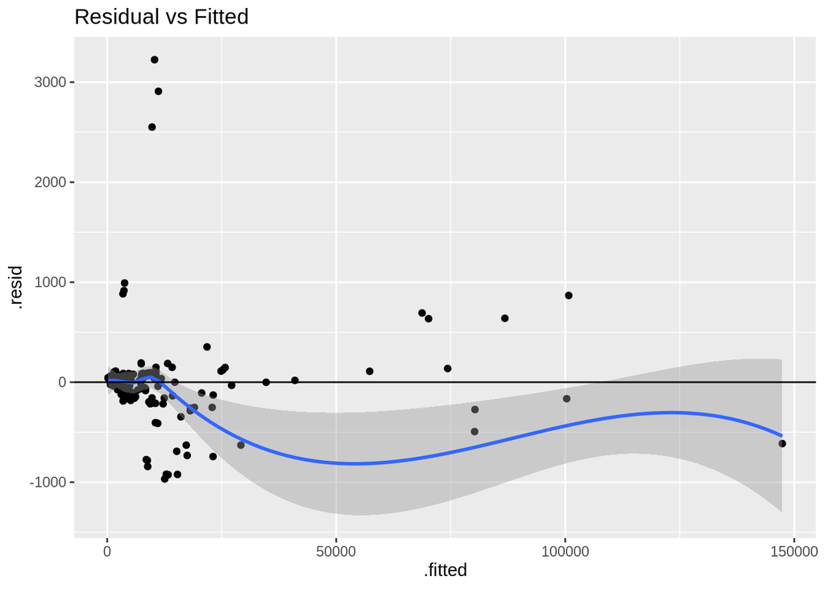

```r
#Linearity Assumption

library(ggplot2)
ggplot(interacmodel2, aes(x=.fitted, y=.resid)) +
  geom_point() + geom_smooth()+
  geom_hline(yintercept = 0)+
  ggtitle("Residual vs Fitted")
```

We can draw the conclusion that, compared to a basic linear regression model, the quadratic model more closely fits the data. Model interpretations are meaningless when the independent variable’s range is exceeded. Despite the fact that the model seems to back up the data. The value of X must fall inside the range of the independent variable in order to generate a forecast for Y. Otherwise, the prediction won’t have any real relevance.

Independence Assumption When subsequent errors are correlated, the assumption of independent errors is broken. This often happens when time-series data, which are observations of data for both dependent and independent variables sequentially over a period of time, are used. Since the objects of our experiment were unrelated to time, we may be quite confident that the measurements are independent.

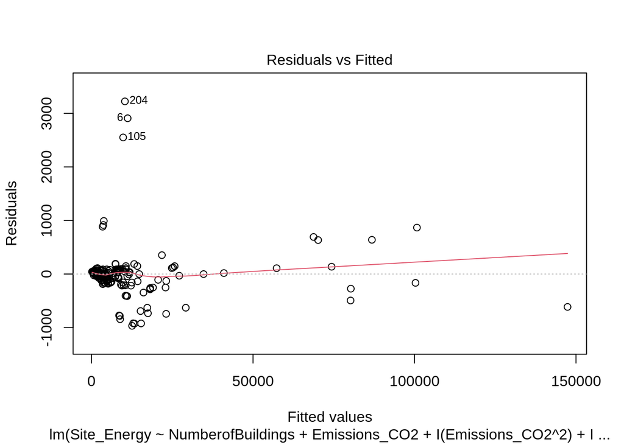

```r
plot(interacmodel2,which=1)
```

```r
library(lmtest)
#H0: heteroscedacity is not present
#H1: Heteroscedacity is present
bptest(interacmodel2)
```

```
##
##  studentized Breusch-Pagan test
##
## data:  interacmodel2
## BP = 93.687, df = 9, p-value = 0.0000000000000002956
```

From our dataset, the output displays the Breusch-Pagan test that results from the cubic model. The p-value = 0.0000000000000002956 <0.05, indicating that we do reject the null hypothesis. Therefore, the test provides very strong evidence to suggest that heteroscedasticity does exist. Therefore, we do the Shapiro-Wilk test.

```r
#H0: the sample data are significantly normally distributed
#Ha: the sample data are not significantly normally distributed
shapiro.test(residuals(interacmodel2))
```

```
##
##  Shapiro-Wilk normality test
##
## data:  residuals(interacmodel2)
## W = 0.49317, p-value < 0.00000000000000022
```

Shapiro-Wilk normality test also confirms that the residuals are NOT normally distributed as the p-value= 0.00000000000000022< 0.05.

Non-normal and Heteroscedastic means we need to do the Box-Cox transformation.

#Influential Outliers

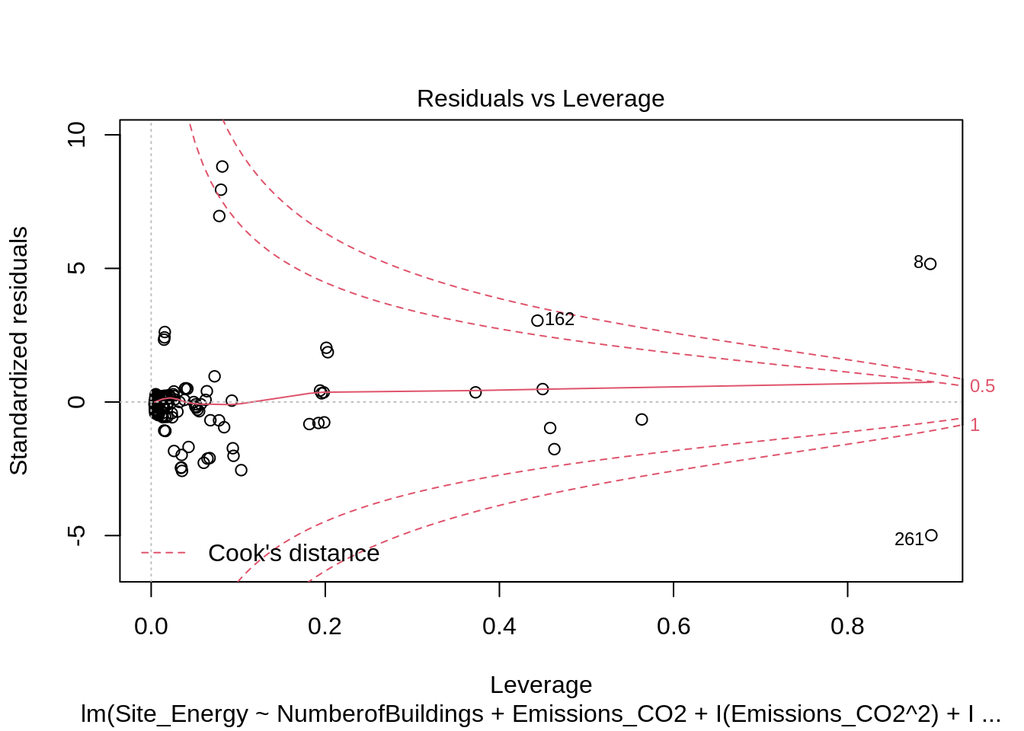

```r
#Influential Outliers

plot(interacmodel2,which=5)
```

```r
dataset[cooks.distance(interacmodel2)>0.5,]
```

```
##     PropertyID                  Property_Type NumberofBuildings Year_Built
## 6      8854296                         Office                 1       1979
## 8      8854298                         Office                 1       1982
## 160   10417704 Fitness Center/Health Club/Gym                 1       1988
## 200    6305956                         Office                 1       1974
## 257   10277262                   Fire Station                 1       1979
## 297   21988629                   Fire Station                 1       1988
##     Property_GFA Site_Energy WeatherNormalizedSiteEnergyUse SiteEUI
## 6        17468.0     14092.5                        13802.8    0.81
## 8        85941.0     87455.3                        85739.7    1.02
## 160       1806.5      3975.2                         4029.3    2.20
## 200       6681.0      4320.7                         4475.4    0.65
## 257       1104.6      1351.2                         1353.1    1.22
## 297        204.4       335.5                          334.6    1.64
##     WeatherNormalizedSiteEUI SourceEnergyUse WeatherNormalizedSourceEnergyUse
```

[output cut: 34 more lines]

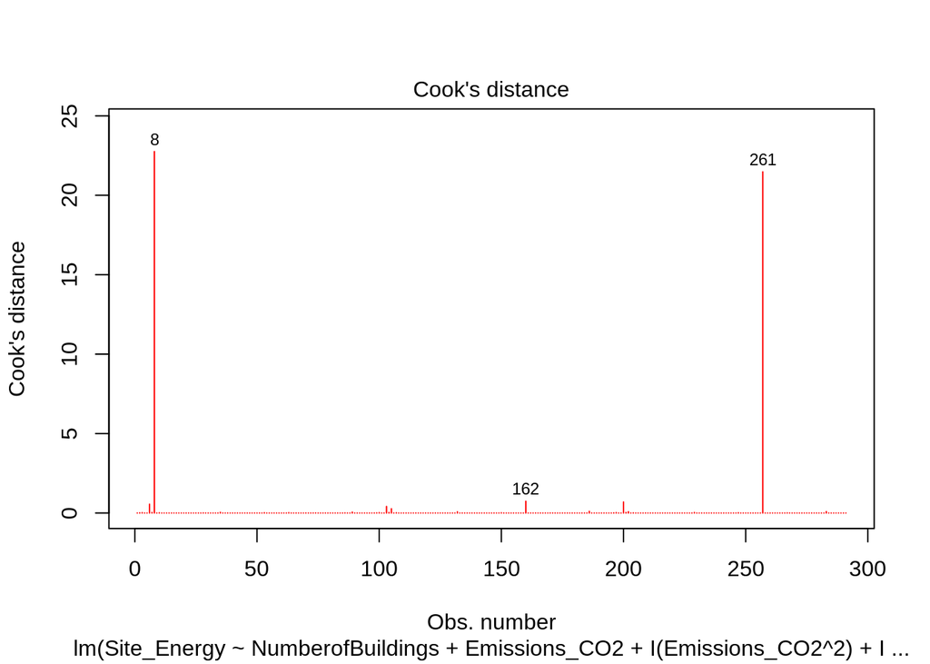

```r
plot(interacmodel2,pch=18,col="red",which=c(4))
```

```r
library(MASS)
bc=boxcox(interacmodel2,lambda=seq(-0.5,3))
```

[figure not shown]

```r
bestlambda=bc$x[which(bc$y==max(bc$y))]
bestlambda
```

```
## [1] 0.5606061
```

```r
library(leaps)
```

```r
library(leaps)
best.subset<-regsubsets(Site_Energy~NumberofBuildings+Emissions_CO2+I(Emissions_CO2^2)+I(Emissions_CO2^3)+Natural_Gas+Property_GFA+Emissions_CO2*Natural_Gas+Emissions_CO2*Property_GFA+Natural_Gas*Property_GFA, data= dataset, nv=9 )

summary(best.subset)
```

```
## Subset selection object
## Call: regsubsets.formula(Site_Energy ~ NumberofBuildings + Emissions_CO2 +
##     I(Emissions_CO2^2) + I(Emissions_CO2^3) + Natural_Gas + Property_GFA +
##     Emissions_CO2 * Natural_Gas + Emissions_CO2 * Property_GFA +
##     Natural_Gas * Property_GFA, data = dataset, nv = 9)
## 9 Variables  (and intercept)
##                            Forced in Forced out
## NumberofBuildings              FALSE      FALSE
## Emissions_CO2                  FALSE      FALSE
## I(Emissions_CO2^2)             FALSE      FALSE
## I(Emissions_CO2^3)             FALSE      FALSE
## Natural_Gas                    FALSE      FALSE
## Property_GFA                   FALSE      FALSE
## Emissions_CO2:Natural_Gas      FALSE      FALSE
## Emissions_CO2:Property_GFA     FALSE      FALSE
## Natural_Gas:Property_GFA       FALSE      FALSE
## 1 subsets of each size up to 9
## Selection Algorithm: exhaustive
##          NumberofBuildings Emissions_CO2 I(Emissions_CO2^2) I(Emissions_CO2^3)
## 1  ( 1 ) " "               "*"           " "                " "
## 2  ( 1 ) " "               "*"           " "                " "
## 3  ( 1 ) " "               "*"           " "                " "
## 4  ( 1 ) " "               "*"           " "                " "
## 5  ( 1 ) " "               "*"           " "                " "
## 6  ( 1 ) " "               "*"           " "                " "
## 7  ( 1 ) " "               "*"           "*"                " "
## 8  ( 1 ) " "               "*"           "*"                "*"
## 9  ( 1 ) "*"               "*"           "*"                "*"
##          Natural_Gas Property_GFA Emissions_CO2:Natural_Gas
## 1  ( 1 ) " "         " "          " "
## 2  ( 1 ) "*"         " "          " "
## 3  ( 1 ) "*"         " "          " "
## 4  ( 1 ) "*"         " "          " "
## 5  ( 1 ) "*"         "*"          " "
## 6  ( 1 ) "*"         "*"          "*"
## 7  ( 1 ) "*"         "*"          "*"
## 8  ( 1 ) "*"         "*"          "*"
## 9  ( 1 ) "*"         "*"          "*"
##          Emissions_CO2:Property_GFA Natural_Gas:Property_GFA
## 1  ( 1 ) " "                        " "
## 2  ( 1 ) " "                        " "
## 3  ( 1 ) "*"                        " "
## 4  ( 1 ) "*"                        "*"
## 5  ( 1 ) "*"                        "*"
## 6  ( 1 ) "*"                        "*"
## 7  ( 1 ) "*"                        "*"
## 8  ( 1 ) "*"                        "*"
## 9  ( 1 ) "*"                        "*"
```

```r
reg.summary<-summary(best.subset)

# for the output interpretation
rsquare<-c(reg.summary$rsq)
cp<-c(reg.summary$cp)
AdjustedR<-c(reg.summary$adjr2)
RMSE<-c(reg.summary$rss)
BIC<-c(reg.summary$bic)
cbind(rsquare,cp,BIC,RMSE,AdjustedR)
```

```
##         rsquare          cp        BIC        RMSE AdjustedR
##  [1,] 0.8377377 89573.99748  -517.8489 13095781714 0.8371763
##  [2,] 0.9951942  2376.45055 -1536.3188   387863215 0.9951608
##  [3,] 0.9990011   270.17256 -1987.7939    80615921 0.9989907
##  [4,] 0.9992723   122.01351 -2074.2802    58732676 0.9992621
##  [5,] 0.9993260    94.24993 -2090.9329    54395119 0.9993142
##  [6,] 0.9994528    26.05778 -2145.8821    44165753 0.9994412
##  [7,] 0.9994741    16.26263 -2151.7610    42446801 0.9994611
##  [8,] 0.9994835    13.04284 -2151.3500    41686100 0.9994688
##  [9,] 0.9994926    10.00000 -2150.8527    40951189 0.9994763
```